Skip to main content

# Maps Collaborative Practice (SOLUTIONS)

Author

Fabulous Student

Published

November 17, 2026

## Getting Started: Plotting a Map of Australia

### 1. Load the Australian states and check the class

- Run the first line to load the ozmap_states object from the {ozmaps} package.
- Then use class() to check that ozmap_states_sf is an sf object.

```r
ozmap_states_sf <- ozmaps::ozmap_states

class(ozmap_states_sf)
```

```
[1] "sf"         "tbl_df"     "tbl"        "data.frame"
```

### 2. Plot ozmap_states_sf

- Give each state a different fill color (*hint:* aes(fill = NAME)).
- Make the outlines of each state white.
- Label each state with geom_label_repel() from {ggrepel} so the labels don’t overlap.
  - *Hint:* geom_label_repel(aes(label = NAME, geometry = geometry), stat = “sf_coordinates”)
- Remove the legend (*hint:* show.legend = FALSE inside geom_sf()).
- Apply theme_void() to remove the background and axes.

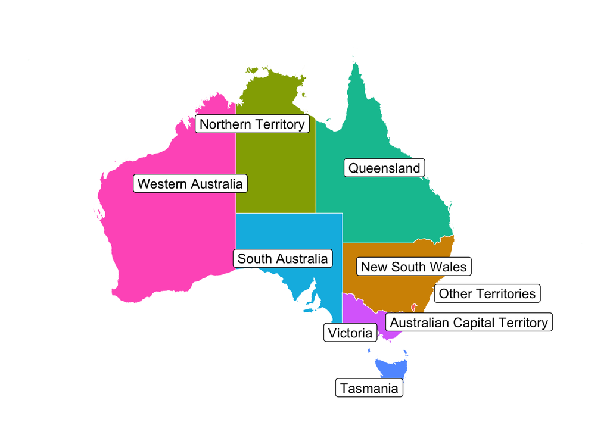

```r
ggplot() +
  geom_sf(data = ozmap_states_sf, aes(fill = NAME), color = "white",
          show.legend = FALSE) +
  geom_label_repel(data = ozmap_states_sf,
                   aes(label = NAME, geometry = geometry),
                   stat = "sf_coordinates", seed = 1) +
  theme_void()
```

### 3. Remove the Australian Capital Territory and Other Territories

- Use filter() to drop the “Australian Capital Territory” and “Other Territories” rows from ozmap_states_sf.
  - *Hint:* filter(!NAME %in% c(…)) keeps every row whose NAME is **not** in the list.
- Copy/paste your code from Step 2 and replot the map.

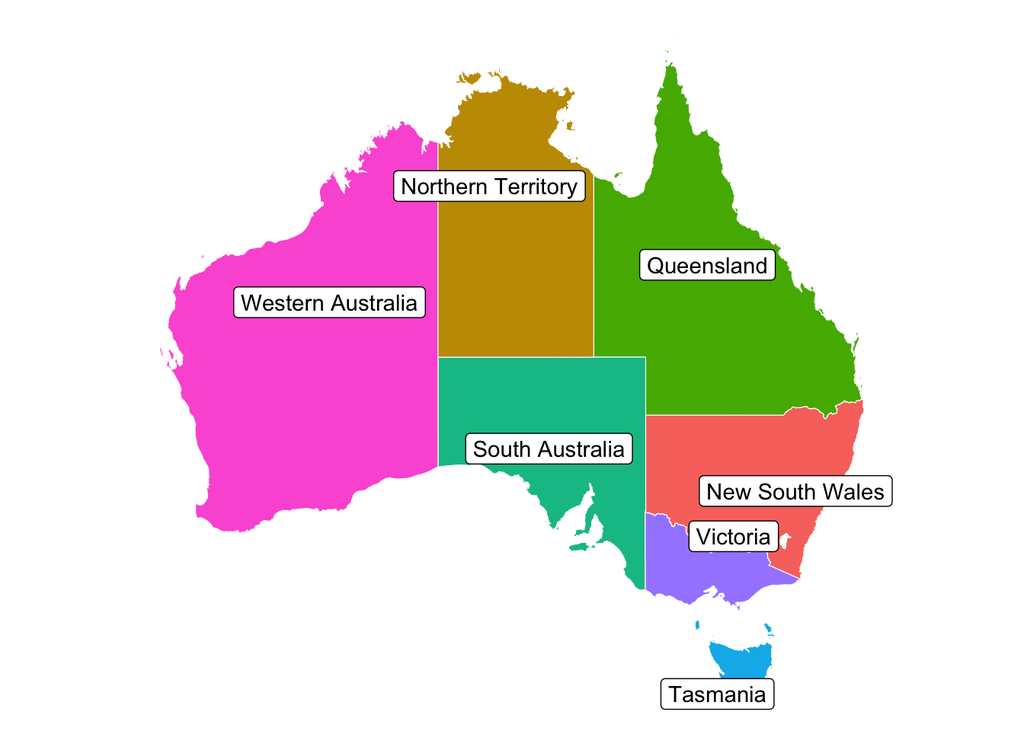

```r
ozmap_states_sf <- ozmap_states_sf |>
  filter(!NAME %in% c("Australian Capital Territory", "Other Territories"))

ggplot() +
  geom_sf(data = ozmap_states_sf, aes(fill = NAME), color = "white",
          show.legend = FALSE) +
  geom_label_repel(data = ozmap_states_sf,
                   aes(label = NAME, geometry = geometry),
                   stat = "sf_coordinates", seed = 1) +
  theme_void()
```

## Case #2: Choropleth Map

### 4. Load and inspect oz_pop.csv

- oz_pop.csv is included in your .zip file. Read it in with read_csv().
- Inspect it and answer the questions below.

```r
oz_pop <- read_csv("oz_pop.csv")

oz_pop
```

```
# A tibble: 8 × 4
  `State/Territory`            Population long_cap lat_cap
  <chr>                             <dbl>    <dbl>   <dbl>
1 New South Wales                 7317500     151.   -33.9
2 Victoria                        5640900     145.   -37.8
3 Queensland                      4599400     153.   -27.5
4 Western Australia               2366900     116.   -32.0
5 South Australia                 1659800     139.   -34.9
6 Tasmania                         511000     147.   -42.9
7 Australian Capital Territory     366900     149.   -35.3
8 Northern Territory               231200     131.   -12.4
```

```r
class(oz_pop)
```

```
[1] "spec_tbl_df" "tbl_df"      "tbl"         "data.frame"
```

**ANSWERS**:

- What variables does it include? State/Territory, Population, long_cap (capital longitude), and lat_cap (capital latitude).
- Is it an sf object? No. It’s a regular tibble/data frame (spec_tbl_df, tbl_df, tbl, data.frame) with no geometry column.
- Which variable could we join on with ozmap_states_sf? What is it called in each dataset? The state/territory name: NAME in ozmap_states_sf and State/Territory in oz_pop.

### 5. Join ozmap_states_sf and oz_pop

- Use left_join() to join the two datasets.
- **Put the sf object first** so the result is still an sf object.
- The join columns have different names, so use by = c(“name_in_sf” = “name_in_csv”), like we did with STATEFP and GEOID in the slides.
  - *Hint:* State/Territory has a / in it, so you’ll need to wrap it in backticks or quotes.

```r
oz_joined_sf <- left_join(ozmap_states_sf, oz_pop,
                          by = c("NAME" = "State/Territory"))

oz_joined_sf
```

```
Simple feature collection with 7 features and 4 fields
Geometry type: MULTIPOLYGON
Dimension:     XY
Bounding box:  xmin: 112.9211 ymin: -43.63203 xmax: 153.6299 ymax: -9.229287
Geodetic CRS:  GDA94
# A tibble: 7 × 5
  NAME                                      geometry Population long_cap lat_cap
  <chr>                           <MULTIPOLYGON [°]>      <dbl>    <dbl>   <dbl>
1 New South Wales    (((150.7016 -35.12286, 150.661…    7317500     151.   -33.9
2 Victoria           (((146.6196 -38.70196, 146.672…    5640900     145.   -37.8
3 Queensland         (((148.8473 -20.3457, 148.8722…    4599400     153.   -27.5
4 South Australia    (((137.3481 -34.48242, 137.374…    1659800     139.   -34.9
5 Western Australia  (((126.3868 -14.01168, 126.362…    2366900     116.   -32.0
6 Tasmania           (((147.8397 -40.29844, 147.890…     511000     147.   -42.9
7 Northern Territory (((136.3669 -13.84237, 136.333…     231200     131.   -12.4
```

```r
class(oz_joined_sf) # still sf because the sf object came first
```

```
[1] "sf"         "tbl_df"     "tbl"        "data.frame"
```

### 6. Make a choropleth map

- Plot the joined data and fill each state by Population.
- Make the outlines of each state white.
- Use scale_fill_viridis_c(labels = scales::label_comma()) and theme_void().

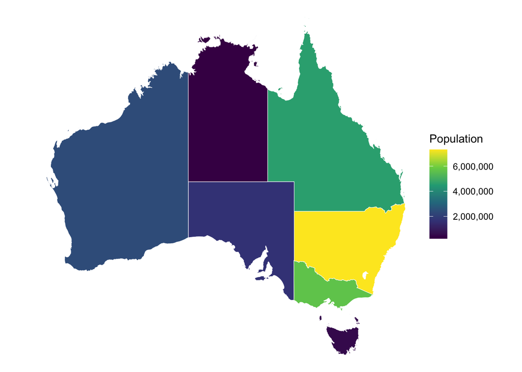

```r
ggplot() +
  geom_sf(data = oz_joined_sf, aes(fill = Population), color = "white") +
  scale_fill_viridis_c(labels = scales::label_comma()) +
  theme_void()
```

## Case #1: Adding Points

### 7. Convert the capitals to an sf object

- oz_pop.csv also has the longitude (long_cap) and latitude (lat_cap) of each state/territory capital.
- We removed the Australian Capital Territory in Step 3, so first use filter() to drop its row from oz_pop too.
  - *Hint:* State/Territory has a / in it, so wrap it in backticks.
- Then pipe the result into st_as_sf() to make a new sf object of points. Use coords = c(“long_cap”, “lat_cap”) (longitude first!) and crs = 4326.
- Use st_crs()$epsg to check the CRS of your new points **and** of ozmap_states_sf.

```r
oz_capitals_sf <- oz_pop |>
  filter(`State/Territory` != "Australian Capital Territory") |>
  st_as_sf(coords = c("long_cap", "lat_cap"), crs = 4326)

class(oz_capitals_sf)
```

```
[1] "sf"         "tbl_df"     "tbl"        "data.frame"
```

```r
st_crs(oz_capitals_sf)$epsg  # we set this with st_as_sf()
```

```
[1] 4326
```

```r
st_crs(ozmap_states_sf)$epsg # came built into {ozmaps}
```

```
[1] 4283
```

**ANSWERS**:

- Do the two objects use the same CRS? No. The capitals use EPSG 4326 (WGS 84), and ozmap_states_sf uses EPSG 4283 (GDA94, an Australian lat/long system).
- Will geom_sf() still line them up? Why? Yes. geom_sf() converts the layers so they match (“projecting on the fly”), just like the Knox County zones (2915) and sites (4326) in the slides.

### 8. Plot the capitals

- Copy/paste your code from Step 6.
- Add a second geom_sf() layer for the capitals. Change the shape, color, and/or size so they stand out from the fill.
- **Question:** In Step 7, we filtered out the capital of the Australian Capital Territory (Canberra). If we hadn’t, would it still show up on the map even though we removed the ACT’s shape in Step 3? Why or why not?

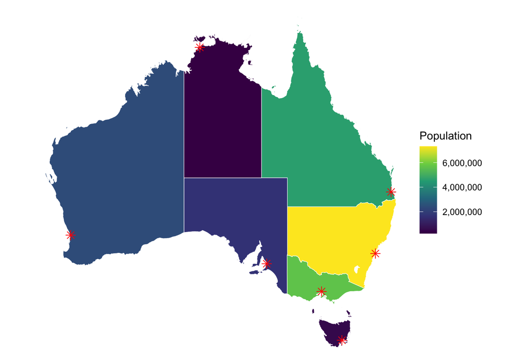

```r
ggplot() +
  geom_sf(data = oz_joined_sf, aes(fill = Population), color = "white") +
  geom_sf(data = oz_capitals_sf, shape = 8, color = "red", size = 3) +
  scale_fill_viridis_c(labels = scales::label_comma()) +
  theme_void()
```

**ANSWER**: Yes. Removing the ACT’s *shape* from ozmap_states_sf doesn’t touch the points, which come from oz_pop. Without the filter(), oz_pop would still have all 8 capitals, so Canberra would plot. It would land inside New South Wales, because the ACT is a small territory surrounded by NSW. Each layer is its own dataset, so you have to filter each one.